# 1. Defining the Question

### a) Specifying the Data Analytic Question

> Identify which individuals are most likely to click on ads from a cryptography course website

### b) Defining the Metric for Success

> For this sttudy, we will perform conclusive Exploratory Data Analysis to enable us identify individuals who are most likely to click on ads.

### c) Understanding the context

> A Kenyan entrepreneur has created an online cryptography course and would want to advertise it on her blog. She currently targets audiences originating from various countries. In the past, she ran ads to advertise a related course on the same blog and collected data in the process. Using the data previously collected, she is looking to do a study to identify which individuals are most likely to click on her ads.

### d) Data Relevance

> Data is provided was collected in the past but from the same blog hence it is very suitable for this study.

> Definition of Variables Daily Time Spent on Site

> Age

> Area Income

> Daily Internet Usage

> Ad Topic Line

> City

> Male

> Country

> Timestamp

> Clicked on Ad

# Reading the data

```r
library("data.table")
ads <- fread('http://bit.ly/IPAdvertisingData')
head(ads)
```

```
##    Daily Time Spent on Site Age Area Income Daily Internet Usage
## 1:                    68.95  35    61833.90               256.09
## 2:                    80.23  31    68441.85               193.77
## 3:                    69.47  26    59785.94               236.50
## 4:                    74.15  29    54806.18               245.89
## 5:                    68.37  35    73889.99               225.58
## 6:                    59.99  23    59761.56               226.74
##                            Ad Topic Line           City Male    Country
## 1:    Cloned 5thgeneration orchestration    Wrightburgh    0    Tunisia
## 2:    Monitored national standardization      West Jodi    1      Nauru
## 3:      Organic bottom-line service-desk       Davidton    0 San Marino
## 4: Triple-buffered reciprocal time-frame West Terrifurt    1      Italy
## 5:         Robust logistical utilization   South Manuel    0    Iceland
## 6:       Sharable client-driven software      Jamieberg    1     Norway
##              Timestamp Clicked on Ad
## 1: 2016-03-27 00:53:11             0
## 2: 2016-04-04 01:39:02             0
## 3: 2016-03-13 20:35:42             0
## 4: 2016-01-10 02:31:19             0
## 5: 2016-06-03 03:36:18             0
## 6: 2016-05-19 14:30:17             0
```

```r
## Checking the summary
summary(ads)
```

```
##  Daily Time Spent on Site      Age         Area Income    Daily Internet Usage
##  Min.   :32.60            Min.   :19.00   Min.   :13996   Min.   :104.8
##  1st Qu.:51.36            1st Qu.:29.00   1st Qu.:47032   1st Qu.:138.8
##  Median :68.22            Median :35.00   Median :57012   Median :183.1
##  Mean   :65.00            Mean   :36.01   Mean   :55000   Mean   :180.0
##  3rd Qu.:78.55            3rd Qu.:42.00   3rd Qu.:65471   3rd Qu.:218.8
##  Max.   :91.43            Max.   :61.00   Max.   :79485   Max.   :270.0
##  Ad Topic Line          City                Male         Country
##  Length:1000        Length:1000        Min.   :0.000   Length:1000
##  Class :character   Class :character   1st Qu.:0.000   Class :character
##  Mode  :character   Mode  :character   Median :0.000   Mode  :character
##                                        Mean   :0.481
##                                        3rd Qu.:1.000
##                                        Max.   :1.000
##    Timestamp                   Clicked on Ad
##  Min.   :2016-01-01 02:52:10   Min.   :0.0
##  1st Qu.:2016-02-18 02:55:42   1st Qu.:0.0
##  Median :2016-04-07 17:27:29   Median :0.5
##  Mean   :2016-04-10 10:34:06   Mean   :0.5
##  3rd Qu.:2016-05-31 03:18:14   3rd Qu.:1.0
##  Max.   :2016-07-24 00:22:16   Max.   :1.0
```

```r
# checking the dimension/shape of the data
dim(ads) # 1000 rows and 10 columns
```

```
## [1] 1000   10
```

```r
#Change datatypes
ads$Male <- as.factor(ads$Male)
#
#Checking datatypes
sapply(ads, class)
```

```
## $`Daily Time Spent on Site`
## [1] "numeric"
##
## $Age
## [1] "integer"
##
## $`Area Income`
## [1] "numeric"
##
## $`Daily Internet Usage`
## [1] "numeric"
##
## $`Ad Topic Line`
## [1] "character"
##
## $City
## [1] "character"
##
## $Male
## [1] "factor"
##
## $Country
## [1] "character"
##
## $Timestamp
## [1] "POSIXct" "POSIXt"
##
## $`Clicked on Ad`
## [1] "integer"
```

# Data cleaning

## Missing values

```r
# checking for missing values
sum(is.na(ads))# there are no missing values in the data
```

```
## [1] 0
```

```r
# displaying all rows from the dataset which don't contain any missing values
na.omit(ads)
```

[output not shown]

[output cut: 21 more lines]

## Duplicates

```r
library(tidyverse)
# Checking the number of duplicates
duplicated_rows <- ads[duplicated(ads),]
duplicated_rows # there are no duplicates in the data
```

```
## Empty data.table (0 rows and 10 cols): Daily Time Spent on Site,Age,Area Income,Daily Internet Usage,Ad Topic Line,City...
```

# Data checking

```r
# Datatypes
sapply(ads,class)
```

```
## $`Daily Time Spent on Site`
## [1] "numeric"
##
## $Age
## [1] "integer"
##
## $`Area Income`
## [1] "numeric"
##
## $`Daily Internet Usage`
## [1] "numeric"
##
## $`Ad Topic Line`
## [1] "character"
##
## $City
## [1] "character"
##
## $Male
## [1] "factor"
##
## $Country
## [1] "character"
##
## $Timestamp
## [1] "POSIXct" "POSIXt"
##
## $`Clicked on Ad`
## [1] "integer"
```

# Checking for outliers

```r
#Checking for outliers
#First we select numeric columns excluding male and clicked.on.ad since they are binary column

ads_df <- subset(ads, select = -c(`Ad Topic Line`,City, Male,   Country,    Timestamp,  `Clicked on Ad`))
head(ads_df)
```

```
##    Daily Time Spent on Site Age Area Income Daily Internet Usage
## 1:                    68.95  35    61833.90               256.09
## 2:                    80.23  31    68441.85               193.77
## 3:                    69.47  26    59785.94               236.50
## 4:                    74.15  29    54806.18               245.89
## 5:                    68.37  35    73889.99               225.58
## 6:                    59.99  23    59761.56               226.74
```

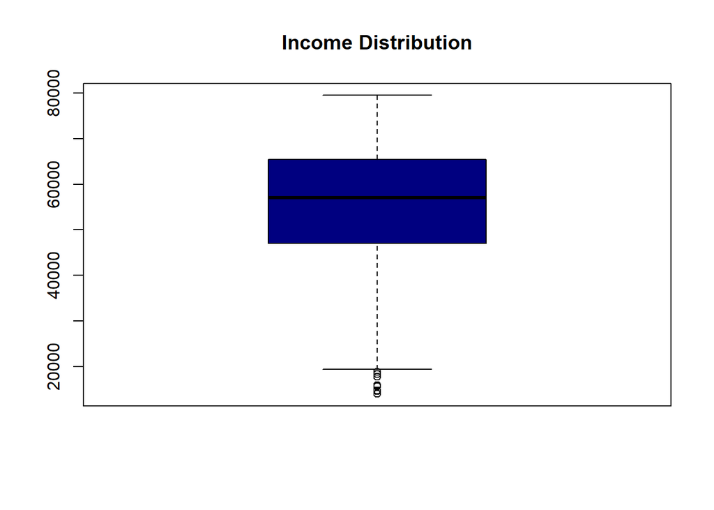

```r
# Then use the function boxplot.stats which lists the outliers in the vectors
# ---
#
options(repr.plot.width = 14, repr.plot.height = 14)
boxplot(ads$`Area Income`,
        col = "navyblue")
# Add a title
title("Income Distribution")
```

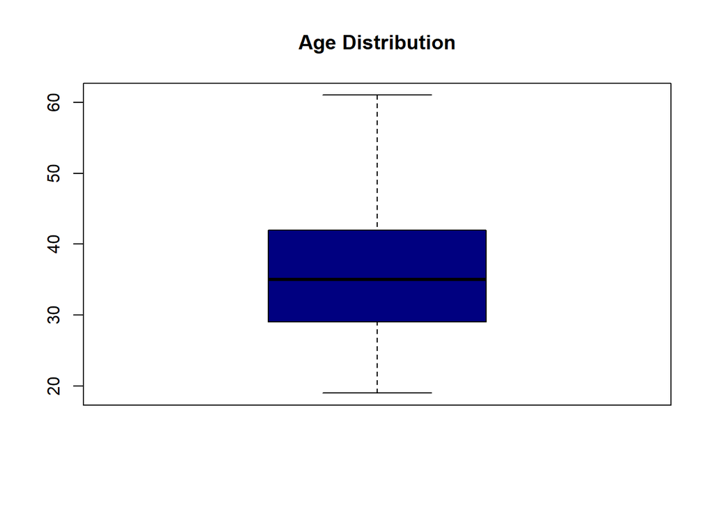

```r
# Then use the function boxplot.stats which lists the outliers in the vectors
# ---
#
options(repr.plot.width = 14, repr.plot.height = 10)
boxplot(ads$`Age`,
        col = "navyblue")
# Add a title
title("Age Distribution")
```

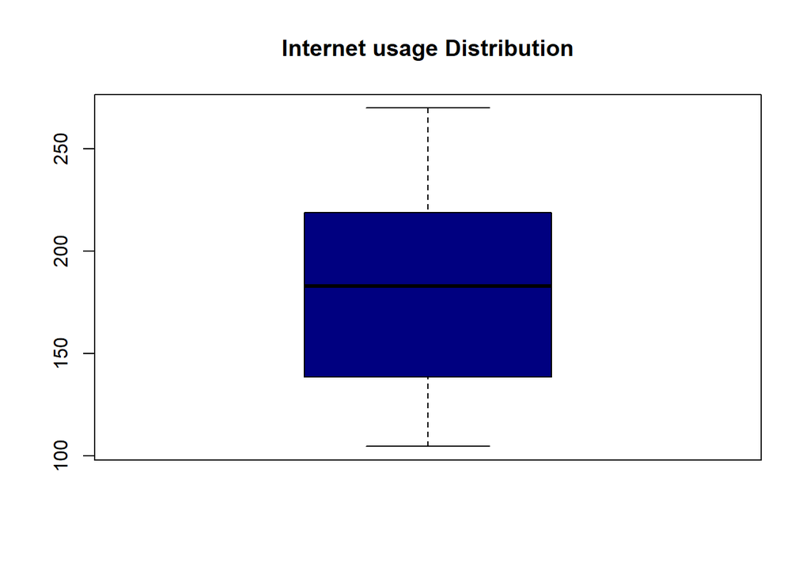

```r
# Then use the function boxplot.stats which lists the outliers in the vectors
# ---
#
options(repr.plot.width = 14, repr.plot.height = 14)
boxplot(ads$`Daily Internet Usage`,
        col = "navyblue")
# Add a title
title("Internet usage Distribution")
```

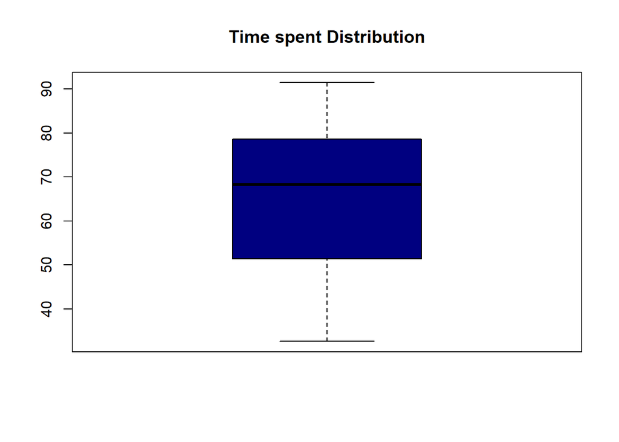

```r
# Then use the function boxplot.stats which lists the outliers in the vectors
# ---
#
options(repr.plot.width = 10, repr.plot.height = 10)
boxplot(ads$`Daily Time Spent on Site`,
        col = "navyblue")
# Add a title
title("Time spent Distribution")
```

```r
class(ads)
```

```
## [1] "data.table" "data.frame"
```

```r
str(ads)
```

```
## Classes 'data.table' and 'data.frame':   1000 obs. of  10 variables:
##  $ Daily Time Spent on Site: num  69 80.2 69.5 74.2 68.4 ...
##  $ Age                     : int  35 31 26 29 35 23 33 48 30 20 ...
##  $ Area Income             : num  61834 68442 59786 54806 73890 ...
##  $ Daily Internet Usage    : num  256 194 236 246 226 ...
##  $ Ad Topic Line           : chr  "Cloned 5thgeneration orchestration" "Monitored national standardization" "Organic bottom-line service-desk" "Triple-buffered reciprocal time-frame" ...
##  $ City                    : chr  "Wrightburgh" "West Jodi" "Davidton" "West Terrifurt" ...
##  $ Male                    : Factor w/ 2 levels "0","1": 1 2 1 2 1 2 1 2 2 2 ...
##  $ Country                 : chr  "Tunisia" "Nauru" "San Marino" "Italy" ...
##  $ Timestamp               : POSIXct, format: "2016-03-27 00:53:11" "2016-04-04 01:39:02" ...
##  $ Clicked on Ad           : int  0 0 0 0 0 0 0 1 0 0 ...
##  - attr(*, ".internal.selfref")=<externalptr>
```

```r
library(tidyverse)
library(DataExplorer)
glimpse(ads)
```

```
## Rows: 1,000
## Columns: 10
## $ `Daily Time Spent on Site` <dbl> 68.95, 80.23, 69.47, 74.15, 68.37, 59.99, 8~
## $ Age                        <int> 35, 31, 26, 29, 35, 23, 33, 48, 30, 20, 49,~
## $ `Area Income`              <dbl> 61833.90, 68441.85, 59785.94, 54806.18, 738~
## $ `Daily Internet Usage`     <dbl> 256.09, 193.77, 236.50, 245.89, 225.58, 226~
## $ `Ad Topic Line`            <chr> "Cloned 5thgeneration orchestration", "Moni~
## $ City                       <chr> "Wrightburgh", "West Jodi", "Davidton", "We~
## $ Male                       <fct> 0, 1, 0, 1, 0, 1, 0, 1, 1, 1, 0, 1, 1, 0, 0~
## $ Country                    <chr> "Tunisia", "Nauru", "San Marino", "Italy", ~
## $ Timestamp                  <dttm> 2016-03-27 00:53:11, 2016-04-04 01:39:02, ~
## $ `Clicked on Ad`            <int> 0, 0, 0, 0, 0, 0, 0, 1, 0, 0, 1, 0, 1, 0, 1~
```

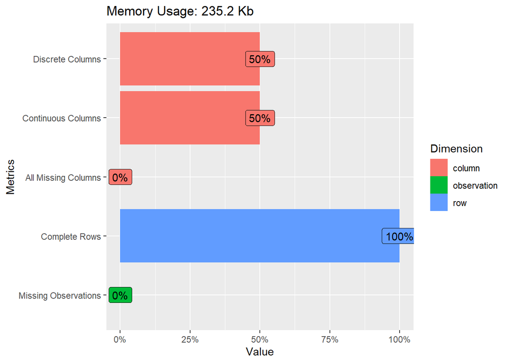

```r
options(repr.plot.width = 10, repr.plot.height = 10)
plot_intro(ads)
```

# Exploratory Data Analysis

## Univariate analysis

##### Measures of central tendency

```r
# descriptive statistics
# these summaries will provide us with the measures of central tendencies of the numerical columns
summary(ads)
```

```
##  Daily Time Spent on Site      Age         Area Income    Daily Internet Usage
##  Min.   :32.60            Min.   :19.00   Min.   :13996   Min.   :104.8
##  1st Qu.:51.36            1st Qu.:29.00   1st Qu.:47032   1st Qu.:138.8
##  Median :68.22            Median :35.00   Median :57012   Median :183.1
##  Mean   :65.00            Mean   :36.01   Mean   :55000   Mean   :180.0
##  3rd Qu.:78.55            3rd Qu.:42.00   3rd Qu.:65471   3rd Qu.:218.8
##  Max.   :91.43            Max.   :61.00   Max.   :79485   Max.   :270.0
##  Ad Topic Line          City           Male      Country
##  Length:1000        Length:1000        0:519   Length:1000
##  Class :character   Class :character   1:481   Class :character
##  Mode  :character   Mode  :character           Mode  :character
##
##
##
##    Timestamp                   Clicked on Ad
##  Min.   :2016-01-01 02:52:10   Min.   :0.0
##  1st Qu.:2016-02-18 02:55:42   1st Qu.:0.0
##  Median :2016-04-07 17:27:29   Median :0.5
##  Mean   :2016-04-10 10:34:06   Mean   :0.5
##  3rd Qu.:2016-05-31 03:18:14   3rd Qu.:1.0
##  Max.   :2016-07-24 00:22:16   Max.   :1.0
```

###### Age

```r
# Finding the mode of age
getmode <- function(v) {
   uniqv <- unique(v)
   uniqv[which.max(tabulate(match(v, uniqv)))]
}

ads.Age.mode <- getmode(ads$Age)
ads.Age.mode
```

```
## [1] 31
```

```r
# Finding the median of age
ads.Age.median <- median(ads$Age)
ads.Age.median
```

```
## [1] 35
```

## Univariate graphical

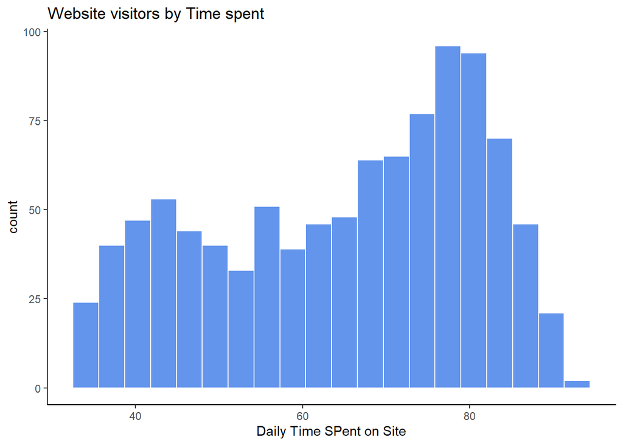

```r
ggplot(ads, aes(x = `Daily Time Spent on Site`)) +
  geom_histogram(fill = "cornflowerblue",
                 color = "white",bins = 20) +
  theme_classic() +                                  # use a minimal theme
  labs(title="Website visitors by Time spent",
       x = "Daily Time SPent on Site")
```

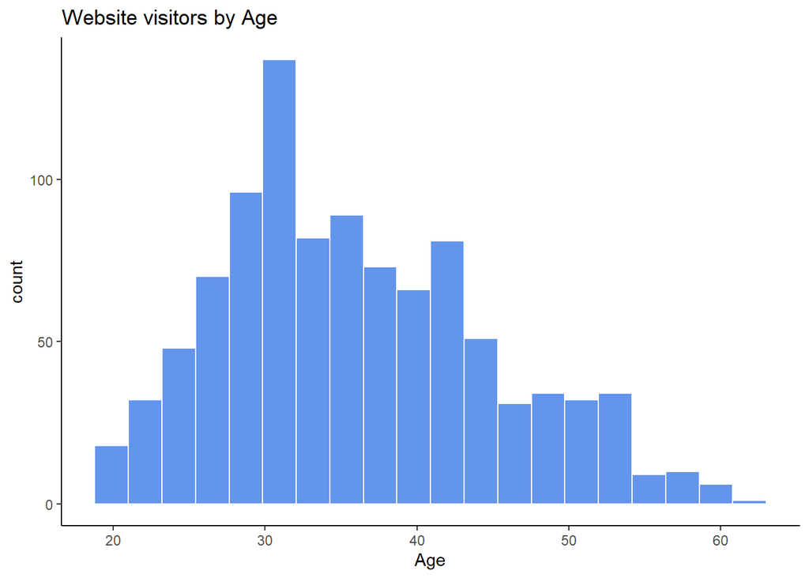

```r
ggplot(ads, aes(x = Age)) +
  geom_histogram(fill = "cornflowerblue",
                 color = "white",bins = 20) +
  theme_classic() +                                  # use a minimal theme
  labs(title="Website visitors by Age",
       x = "Age")
```

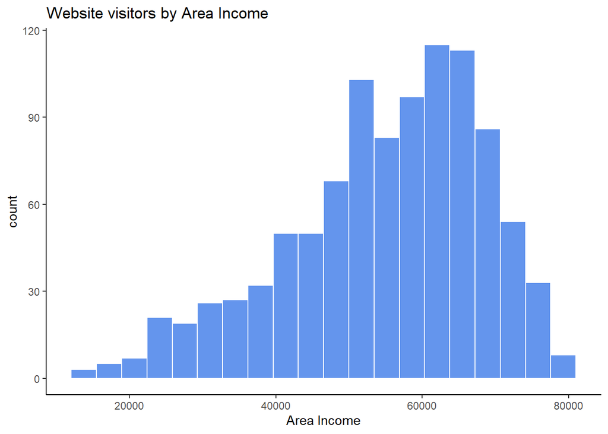

```r
library(ggplot2)                                     # for visualization
ggplot(ads, aes(x = `Area Income`)) +
  geom_histogram(fill = "cornflowerblue",
                 color = "white",bins = 20) +
  theme_classic() +                                  # use a minimal theme
  labs(title="Website visitors by Area Income",
       x = "Area Income")
```

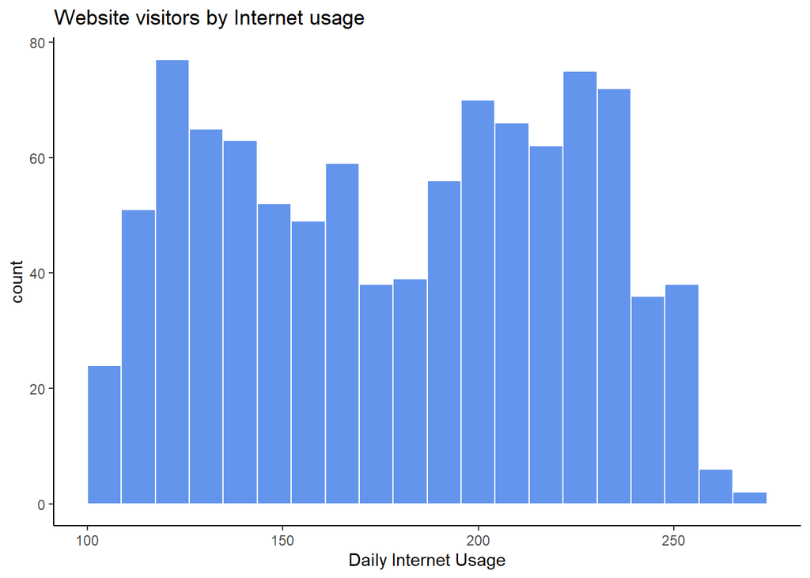

```r
library(ggplot2)                                     # for visualization
ggplot(ads, aes(x = `Daily Internet Usage`)) +
  geom_histogram(fill = "cornflowerblue",
                 color = "white",bins = 20) +
  theme_classic() +                                  # use a minimal theme
  labs(title="Website visitors by Internet usage",
       x = "Daily Internet Usage")
```

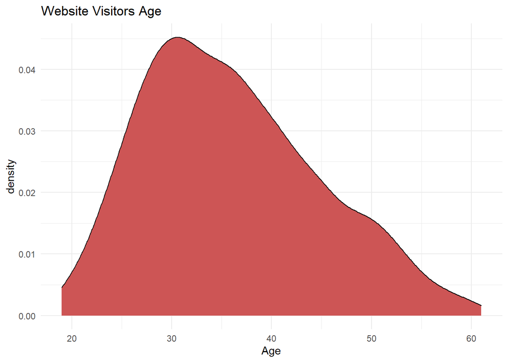

```r
library(ggplot2)                                     # for visualization
ggplot(ads, aes(x = Age)) +
  geom_density(fill = "indianred3") +
  theme_minimal() +                                  # use a minimal theme
  labs(title = "Website Visitors Age")
```

###### Categorical data

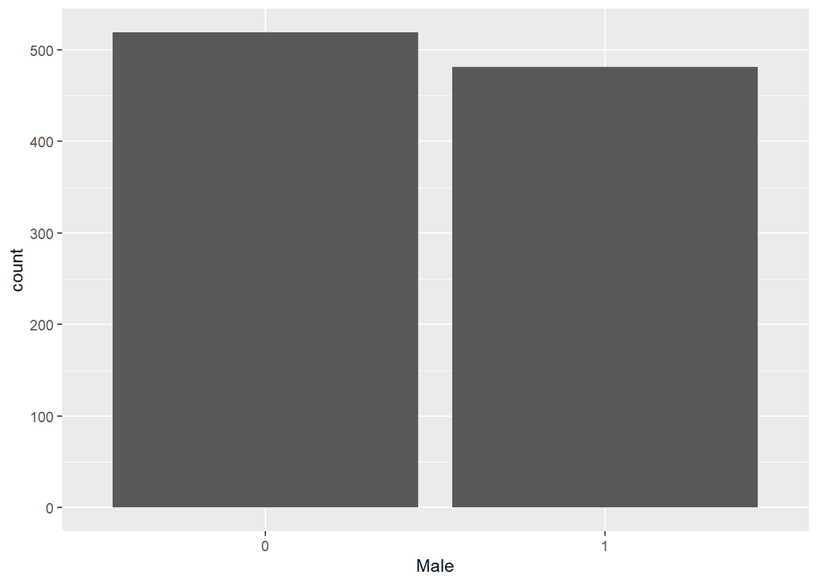

```r
#Which gender is mainly active on the blog?
ggplot(data = ads) +
  geom_bar(mapping = aes(x = Male))
```

```r
#Assuming that if male = 1 then we can conclude that more females
# frequent the blog more as compared to males
```

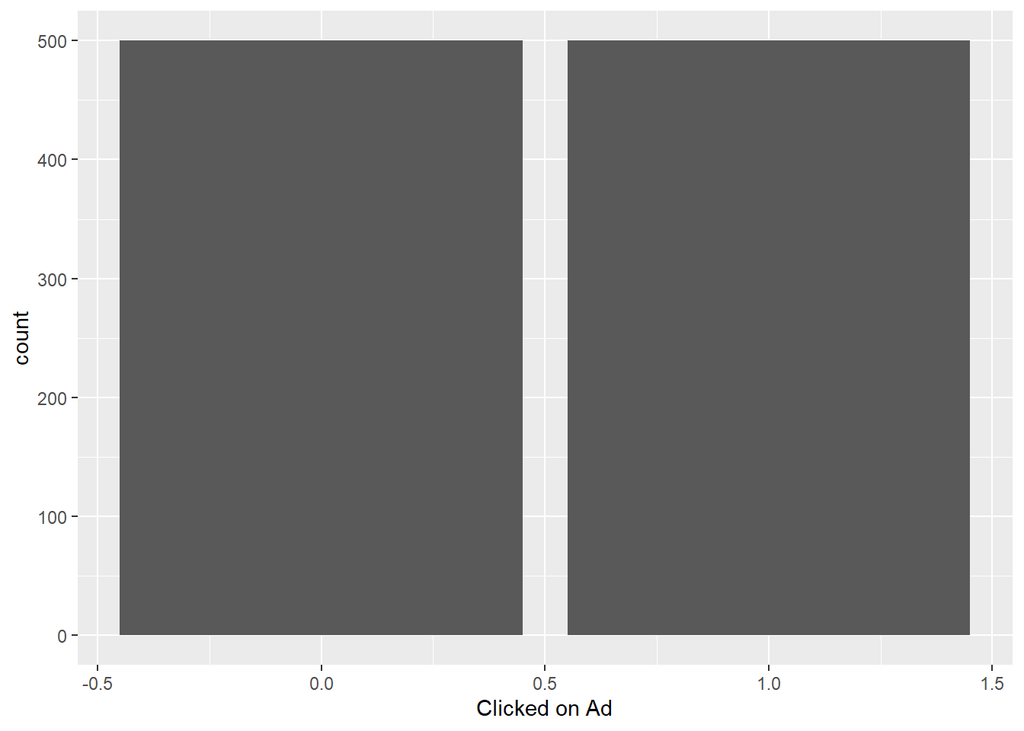

```r
#Do most people clickon ads or not?
ggplot(data = ads) +
  geom_bar(mapping = aes(x = `Clicked on Ad`))
```

```r
#There is a balance between the people who click on ads and those who don't
#We can coclude that half of the people who visit the website will probably click on an ad
```

## Bivariate analysis and Mulitivariate analysis

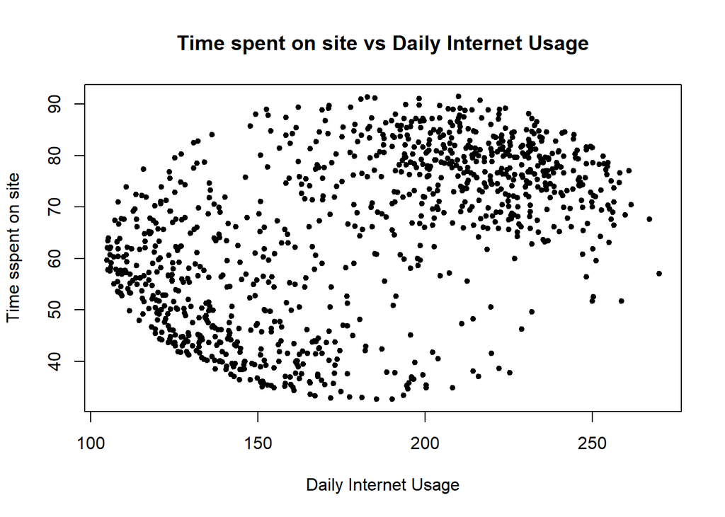

```r
x <- ads$`Daily Internet Usage`
y <-  ads$`Daily Time Spent on Site`
# Plot with main and axis titles
# Change point shape (pch = 19) and remove frame.
plot(x, y, main = "Time spent on site vs Daily Internet Usage",
     xlab = "Daily Internet Usage", ylab = "Time sspent on site",
     pch = 20)
```

> The points are all over but our data points are not highly correlated which explains this. But we can see that people who spend less time on site use less internet. Also, most of the people who use alot of internet per day seem to spend a considerable amount of time on the site. This is a good sign for the business

##### Explore which individuals are most likely to click an ad

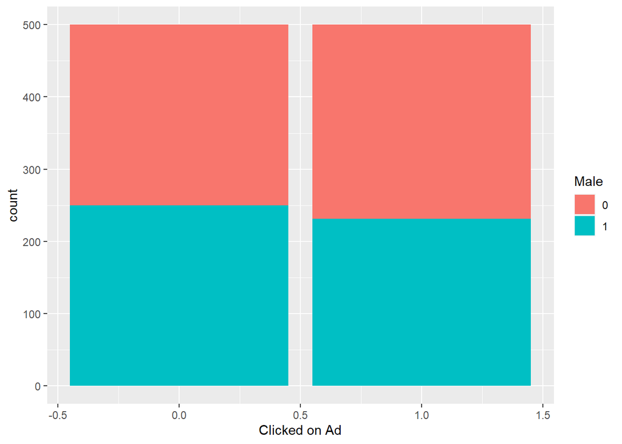

```r
#Who is likely to click on an ad, female or male?
library(ggplot2)

# stacked bar chart
ggplot(ads,
       aes(x = `Clicked on Ad`,
           fill = Male)) +
  geom_bar(position = "stack")
```

> From above graph, we can see that female(where male=0), is slightly more likely to click on an ad that male. But also from earlier analysis, it is important to note that females are slightly more frequent on the blog than male.

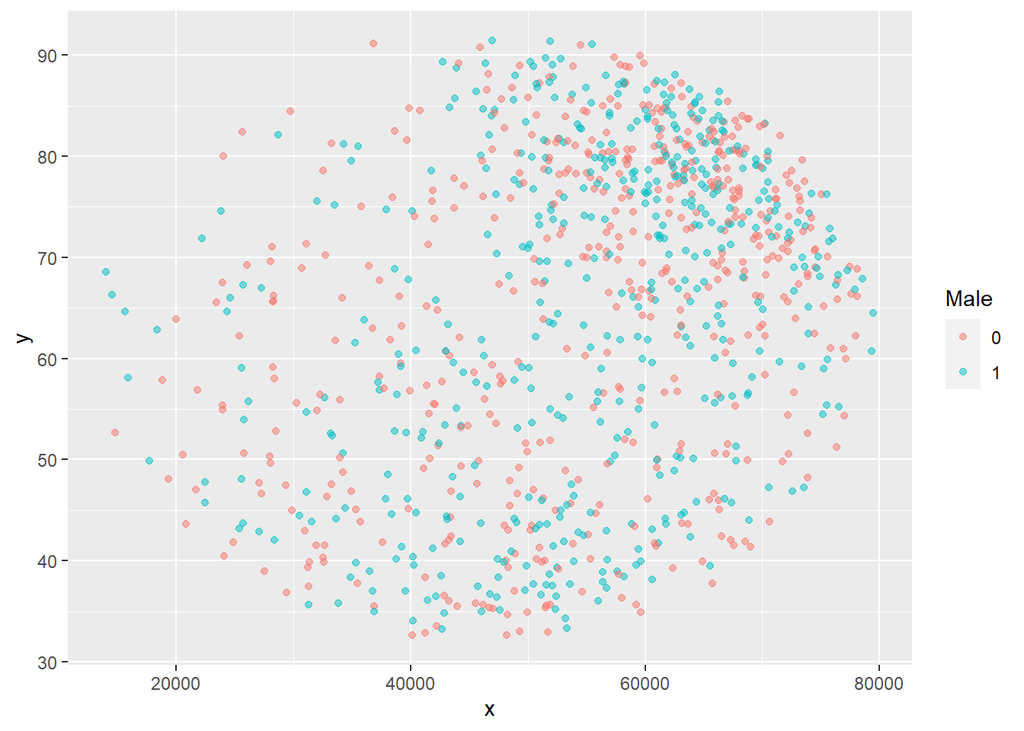

```r
x <- ads$`Area Income`
y <- ads$`Daily Time Spent on Site`
ggplot(ads,aes(x,y,color=`Male`))+geom_point(alpha=0.5)
```

```r
# finding the correlation
#rquery.cormat(df1, type="full")
res <- cor(ads_df)
round(res, 2)
```

```
##                          Daily Time Spent on Site   Age Area Income
## Daily Time Spent on Site                     1.00 -0.33        0.31
## Age                                         -0.33  1.00       -0.18
## Area Income                                  0.31 -0.18        1.00
## Daily Internet Usage                         0.52 -0.37        0.34
##                          Daily Internet Usage
## Daily Time Spent on Site                 0.52
## Age                                     -0.37
## Area Income                              0.34
## Daily Internet Usage                     1.00
```

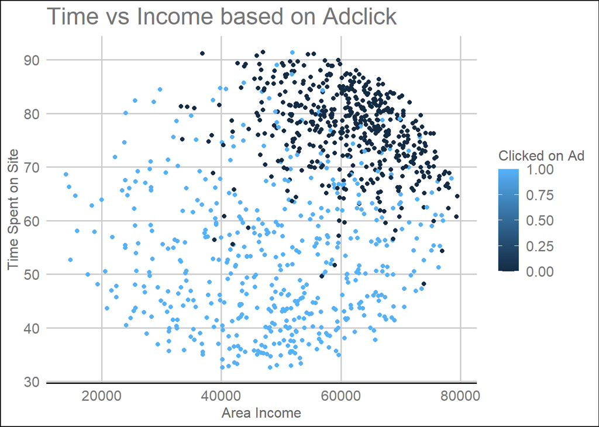

```r
# Scatter Plot for Time vs Income based on adclicks

library(ggthemes)
library(ggplot2)
options(repr.plot.width = 10, repr.plot.height = 10)
ggplot(data = ads, mapping = aes(`Area Income` , `Daily Time Spent on Site`)) +
    geom_point(alpha = 10, aes(color = `Clicked on Ad`)) + theme_gdocs() +
     labs(title = "Time vs Income based on Adclick",
     x = "Area Income", y = "Time Spent on Site")
```

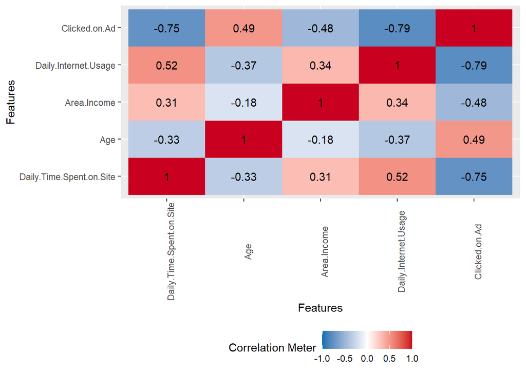

```r
library(corrplot)
library(DataExplorer)
options(repr.plot.width = 20, repr.plot.height = 20)
plot_correlation(ads, type = 'c',cor_args = list( 'use' = 'complete.obs'))
```

### 6. Conclusion

> People who have a daily internet usage of less than 175 are more likely to click on an ad People who spend less than 70mins on the site are likely to click on ad People above 40 are more likely to click on an ad People with an income of less than 60000 are most likely to click on an ad The female gender is likely to click on ad

### 7. Challenging the solution

> It would be great to do some hypothesis testing on the conclusions made from Exploratory Data Analysis, this way we could ascertain the chances of specific person clicking on an ad or not. Also, it would be necessary to create a predictive model and perform some feature importance selection to choose which variables are most important to use when deciding who will click on an ad or not when using the website.